# UNICEF Global Issue Report

Author

Thimothy Fernandes

# A Demographic Analysis of Global Child Populations

This report examines the geographic distribution and historical trends of child and youth populations worldwide, revealing where the world’s youngest citizens are concentrated and how these patterns have evolved over six decades. The analysis highlights a dramatic shift toward Asia and Africa, where countries like India, China, and Nigeria now host the largest child populations, while growth rates signal both demographic momentum and emerging stabilization. Understanding these dynamics is essential for UNICEF and policymakers to strategically allocate resources and plan for the educational, healthcare, and economic needs of future generations.

## Import Libraries

```python
# Import libraries
import polars as pl
from plotnine import *
import matplotlib.pyplot as plt
import geopandas as gpd
import warnings
warnings.filterwarnings('ignore')

# Set plot styling
theme_set(theme_minimal())
%matplotlib inline
```

## Load Data

```python
# Loading data with Polars
df = pl.read_csv("unicef_indicator_1.csv")

# Displaying first 5 rows
print("First 5 rows:")
print(df.head())

# Checking column names
print("\nColumn names:")
print(df.columns)
```

```
First 5 rows:
shape: (5, 14)
┌───────────┬───────────┬───────────┬───────────┬───┬───────────┬───────────┬───────────┬──────────┐
│ country   ┆ alpha_2_c ┆ alpha_3_c ┆ numeric_c ┆ … ┆ observati ┆ observati ┆ time_peri ┆ current_ │
│ ---       ┆ ode       ┆ ode       ┆ ode       ┆   ┆ on_status ┆ on_confid ┆ od_activi ┆ age      │
│ str       ┆ ---       ┆ ---       ┆ ---       ┆   ┆ ---       ┆ entaility ┆ ty_relate ┆ ---      │
│           ┆ str       ┆ str       ┆ i64       ┆   ┆ str       ┆ ---       ┆ d_t…      ┆ str      │
│           ┆           ┆           ┆           ┆   ┆           ┆ str       ┆ ---       ┆          │
│           ┆           ┆           ┆           ┆   ┆           ┆           ┆ str       ┆          │
╞═══════════╪═══════════╪═══════════╪═══════════╪═══╪═══════════╪═══════════╪═══════════╪══════════╡
│ Afghanist ┆ AF        ┆ AFG       ┆ 4         ┆ … ┆ Predicted ┆ null      ┆ null      ┆ Total    │
│ an        ┆           ┆           ┆           ┆   ┆           ┆           ┆           ┆          │
│ Afghanist ┆ AF        ┆ AFG       ┆ 4         ┆ … ┆ Predicted ┆ null      ┆ null      ┆ Total    │
│ an        ┆           ┆           ┆           ┆   ┆           ┆           ┆           ┆          │
│ Afghanist ┆ AF        ┆ AFG       ┆ 4         ┆ … ┆ Predicted ┆ null      ┆ null      ┆ Total    │
│ an        ┆           ┆           ┆           ┆   ┆           ┆           ┆           ┆          │
│ Afghanist ┆ AF        ┆ AFG       ┆ 4         ┆ … ┆ Predicted ┆ null      ┆ null      ┆ Total    │
│ an        ┆           ┆           ┆           ┆   ┆           ┆           ┆           ┆          │
│ Afghanist ┆ AF        ┆ AFG       ┆ 4         ┆ … ┆ Predicted ┆ null      ┆ null      ┆ Total    │
│ an        ┆           ┆           ┆           ┆   ┆           ┆           ┆           ┆          │
└───────────┴───────────┴───────────┴───────────┴───┴───────────┴───────────┴───────────┴──────────┘

Column names:
['country', 'alpha_2_code', 'alpha_3_code', 'numeric_code', 'indicator', 'time_period', 'obs_value', 'sex', 'unit_multiplier', 'unit_of_measure', 'observation_status', 'observation_confidentaility', 'time_period_activity_related_to_when_the_data_are_collected', 'current_age']
```

## Data Cleaning

```python
# Data cleaning with Polars
# Removing missing values
df = df.filter(pl.col('obs_value').is_not_null())

# Converting time_period to numeric
df = df.with_columns(
    pl.col('time_period').cast(pl.Int64, strict=False)
)

# Converting obs_value to numeric
df = df.with_columns(
    pl.col('obs_value').cast(pl.Float64, strict=False)
)

# Filtering for latest year (2023)
df_2023 = df.filter(pl.col('time_period') == 2023)

print(f"Total rows after cleaning: {df.shape[0]}")
print(f"Rows for 2023: {df_2023.shape[0]}")
```

```
Total rows after cleaning: 50616
Rows for 2023: 684
```

## 📊 VISUALISATIONS

### 1. 🌍 WORLD MAP

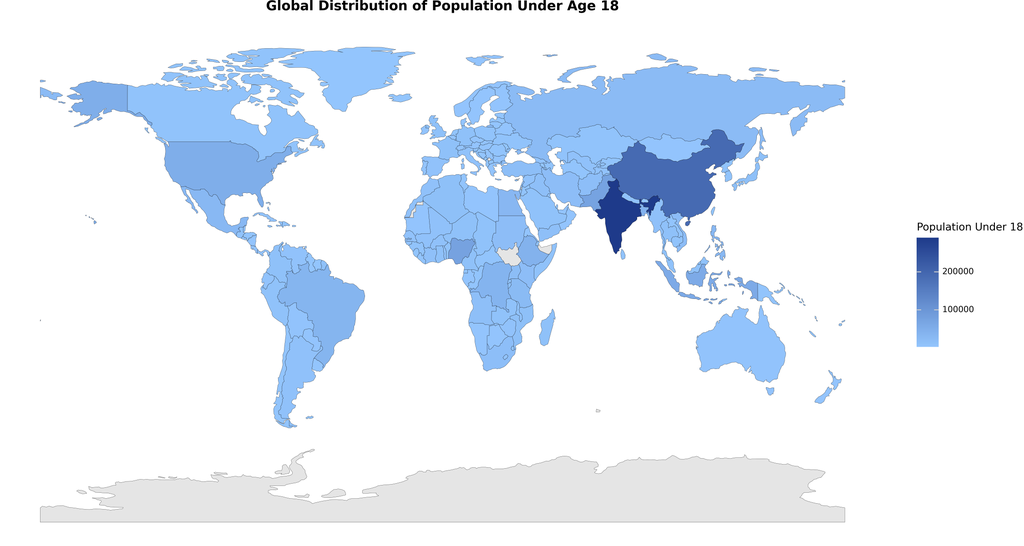

```python
#World Map using plotnine + GeoPandas
# Download and load world map
import urllib.request
import zipfile
import os

# Checking if already downloaded to avoid re-downloading
if not os.path.exists("ne_110m_admin_0_countries.zip"):
    url = "https://naturalearth.s3.amazonaws.com/110m_cultural/ne_110m_admin_0_countries.zip"
    urllib.request.urlretrieve(url, "ne_110m_admin_0_countries.zip")

if not os.path.exists("ne_110m_admin_0_countries"):
    with zipfile.ZipFile("ne_110m_admin_0_countries.zip", 'r') as zip_ref:
        zip_ref.extractall("ne_110m_admin_0_countries")

# Loading the shapefile directly
world = gpd.read_file("ne_110m_admin_0_countries/ne_110m_admin_0_countries.shp")

# Preparing the data
map_data = (df_2023
    .group_by(['country', 'alpha_3_code'])
    .agg(pl.col('obs_value').mean().alias('population'))
    .drop_nulls()
    .to_pandas()
)

# Merging using the ADM0_A3 column
map_df = world.merge(
    map_data,
    left_on='ADM0_A3',
    right_on='alpha_3_code',
    how='left'
)

# Creating the plot with customized colours
world_plot = (
    ggplot(map_df) +
    geom_map(aes(fill='population', geometry='geometry'), size=0.1) +
    scale_fill_gradient(
        low='#93c5fd',      # Light blue for lower values
        high='#1e3a8a',     # Deep blue for higher values
        na_value='#e5e5e5', # Light grey for missing data
        name="Population Under 18"
    ) +
    theme_void() +
    labs(
        title="Global Distribution of Population Under Age 18"
    ) +
    theme(
        plot_title=element_text(size=14, face='bold'),
        figure_size=(15, 8)
    )
)

# Saving the map as PNG and displaying it
world_plot.save("world_map.png", dpi=300)
from IPython.display import Image
Image("world_map.png")
```

**Insight:**

-Countries like India and China show the highest values, indicating very large populations under age 18 concentrated in Asia.

-Most regions in Africa display moderate levels, reflecting a young population but smaller absolute totals per country compared to Asia.